# H1 Policy Comparison: Strict Priority Reservations

Policies optimized for average appointment utilization

## Main findings

- **Most policy comparisons are ties.** Both-flexible improves on baseline in 26.1% of backgrounds and is practically tied in 73.9%.
- **Large gains are concentrated under heavy demand.** The median both-flexible gain is 0.19 pp overall, but the upper-demand scenarios contain the large improvements.
- **Neither single policy uniformly dominates.** Reservation-only beats horizon-only in 92 backgrounds, horizon-only beats reservation-only in 86, and they tie in 662.
- **Reservations often redistribute access.** Priority served rate rises while general-group served rate falls in 32.4% of reservation-only comparisons with baseline.
- **The twice-weighted Class 1 objective is materially different.** Exact policy cells match only 16.9% of the time for reservation-only and 13.0% for both-flexible.

## How the simulations were run

- **840 backgrounds:** 42 anchor settings and 798 Sobol-sampled settings.
- A **policy cell** is one exact combination of booking horizon, reserved quantity, and reservation-window length.
- Every evaluated policy cell was run with **10 paired seeds**, so competing policies were compared under the same random seeds.
- The final postprocessed file contains **67,200 selected-policy seed records per reservation rule**: 840 backgrounds × 4 policies × 2 optimization objectives × 10 seeds. These are the selected outcomes; the optimizer ran additional candidate cells before choosing each optimum.
- Demand-to-capacity ratio ranged from **0.8 to 3.0**; priority-group share ranged from **0.1 to 0.9**.
- Daily capacity ranged from **20 to 50 slots** and the native horizon ranged from **2 to 26 days**.
- Cancellation, balking, and no-show behavior varied across both groups.
- Paired bootstrap intervals used **2,000 draws**. Bootstrap draws are resamples of the paired seed differences, not additional simulation runs. A difference within **0.005** utilization was treated as a practical tie.

### Problem parameters

The 840 backgrounds were sampled from the following parameter grid. The design was not a full factorial: it combined 42 anchor scenarios with 798 Sobol-sampled scenarios.

| Parameter | Tested values |
| --- | --- |
| Demand-to-capacity ratio (ρ) | 0.8, 1.0, 1.2, 1.4, 1.6, 2.0, 3.0 |
| Native booking horizon (days) | 2, 6, 10, 14, 18, 22, 26 |
| Priority-group share (Class 1) | 0.1, 0.3, 0.5, 0.7, 0.9 |
| Daily capacity (slots/day) | 20, 30, 40, 50 |
| Cancellation probability (per class) | 0.1, 0.2, 0.3 |
| Balking threshold (per class, days) | 5, 9, 16, 22, 24 |
| Pre-threshold balking probability (per class) | 0.05, 0.1, 0.2, 0.3 |
| Post-threshold balking probability (per class) | 0.1, 0.2, 0.3, 0.4 |
| No-show threshold (per class, days) | 4, 7, 14, 20, 22 |
| Pre-threshold no-show probability (per class) | 0.05, 0.1, 0.2, 0.3 |
| Post-threshold no-show probability (per class) | 0.1, 0.2, 0.3, 0.4 |

The cancellation, balking, and no-show parameters were sampled separately for Class 1 and Class 2. Valid sampled backgrounds required each post-threshold probability to exceed its corresponding pre-threshold probability and each class’s balking threshold to exceed its no-show threshold. When a sampled threshold was outside a tested booking horizon, the simulation capped it at the active horizon minus one day.

### Policy-search parameters

The optimized policy search used:

| Policy parameter | Candidate values |
| --- | --- |
| Booking horizon | 2, 6, 10, 14, 18, 22, 26 days |
| Reserved quantity Q | 0 to daily capacity; positive Q searched coarsely in steps of 5 and refined in steps of 1 |
| Reservation-window length | 1 day through the selected horizon; searched coarsely in steps of 2 and refined in steps of 1 |

The four policy regimes were:

| Policy | Booking horizon | Priority reservations |
| --- | --- | --- |
| Baseline | Fixed at the background value | None |
| Horizon only | Optimized | None |
| Reservation only | Fixed at the background value | Quantity and reservation window optimized |
| Both flexible | Optimized | Quantity and reservation window optimized |

The primary objective was **average utilization**:

> **Average utilization** = **completed appointments** ÷ **available measured appointment slots**

Class 1 and Class 2 remain different simulated patient populations in every regime. Class 1 is called the **priority group** only when `Q > 0`. When `Q = 0`, both groups book through the general first-come-first-served pool.

## Overall policy comparison

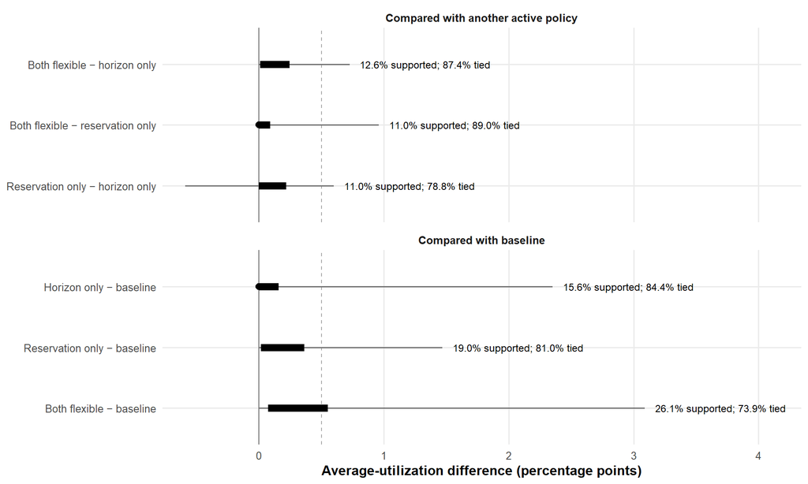

Figure 1: Distribution of average-utilization differences across all six policy comparisons. Points show medians, thick lines show interquartile ranges, and thin lines show the 10th–90th percentiles.

- Both-flexible weakly contains the other policy choices, so it cannot be worse after optimization.
- That does **not** mean both policies are always needed. Most backgrounds are practical ties.
- Reservation-only and horizon-only should be read as competing single-policy options, not as a ranking that applies to every clinic.

| Comparison | Median difference | Supported increase | Practical tie |
| --- | --- | --- | --- |
| Both flexible − baseline | 0.19 pp | 26.1% | 73.9% |
| Both flexible − horizon only | 0.10 pp | 12.6% | 87.4% |
| Both flexible − reservation only | 0.00 pp | 11.0% | 89.0% |
| Horizon only − baseline | 0.00 pp | 15.6% | 84.4% |
| Reservation only − baseline | 0.14 pp | 19.0% | 81.0% |
| Reservation only − horizon only | 0.06 pp | 11.0% | 78.8% |

## Which scenarios benefit?

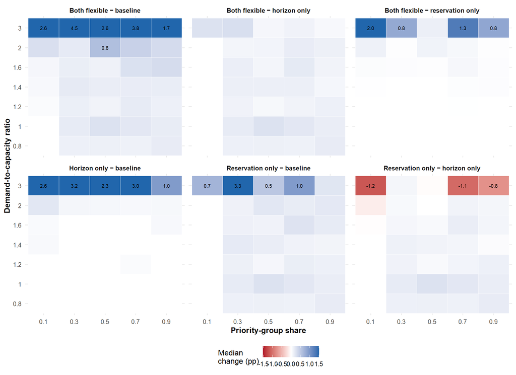

Figure 2: Median average-utilization difference by demand pressure and priority-group share. Values are aggregated over the remaining scenario parameters.

The dominant pattern is demand pressure:

- At low and moderate demand, the policies are usually tied in utilization.
- The clearest gains appear when demand approaches the upper end of the tested range.
- Priority-group share changes which single policy performs better, but it does not create one universal winner.

### No-show behavior and reservation value

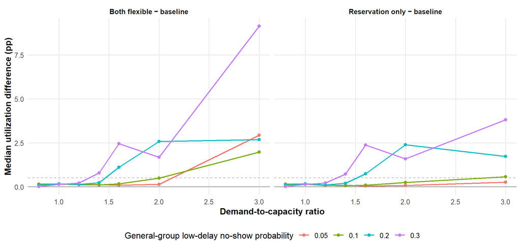

Figure 3: Reservation-related gains rise under heavy demand when the general group has a higher low-delay no-show probability. These are grouped associations across backgrounds, not isolated one-parameter causal effects.

The lines connect grouped medians rather than following the same backgrounds as demand changes. For the 0.30 general-group no-show line in the both-flexible panel, the 1.6 point summarizes 11 backgrounds and the 2.0 point summarizes 8. The medians move from 2.46 pp to 1.68 pp, while the means move from 2.35 pp to 2.31 pp. The visible dip is therefore mainly a median-and-composition effect, not evidence that raising demand from 1.6 to 2.0 reduces reservation value. Each point contains a different mixture of horizons, capacities, group shares, thresholds, cancellation rates, and balking behavior. The same caution applies to the reservation-only panel.

Under strict reservations:

- Horizon flexibility has little median effect until demand becomes very high.
- Reservation gains rise when the general group has a high low-delay no-show probability, especially once demand exceeds capacity.
- At a demand-to-capacity ratio of 3.0, the median reservation-only gain ranges from about **0.3 pp** when the general-group low-delay no-show probability is 0.05 to about **3.8 pp** when it is 0.30.
- The no-show thresholds and other behavioral parameters modify the result, but their patterns are weaker and less uniform than demand pressure.

## Optimized policy parameters

The figure below focuses on **both-flexible**, where the horizon, reserved quantity, and reservation window were jointly selected.

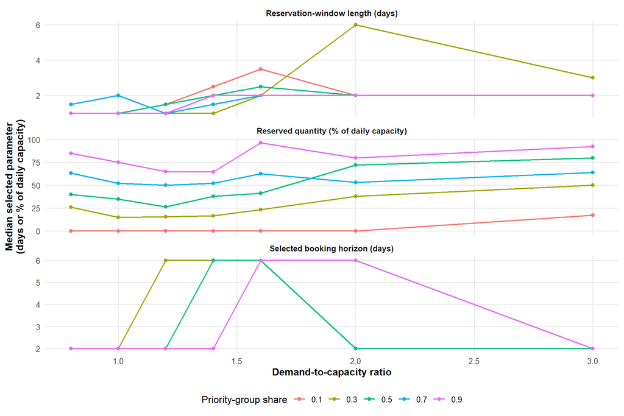

Figure 4: Median jointly optimized parameters for the both-flexible policy. Lines connect different background groups and candidate values are discrete; they should not be read as smooth response curves.

These lines also connect grouped medians over a discrete search grid; they are not smooth response curves. At a demand-to-capacity ratio of 2.0 and a priority-group share of 0.3, the six-day reservation-window point summarizes 20 backgrounds with positive reservations. Their selected windows range from 1 to 14 days. Six days is therefore the middle of a wide distribution, not a uniquely preferred window for every 30% priority-group scenario. A plausible mechanism is that a moderate priority share sometimes needs a longer near-term window to expose enough Class 1 arrivals to reserved capacity, whereas a very small priority group makes reservations harder to fill and a large priority group can fill them within a shorter window. Because the remaining scenario parameters also vary, this figure does not isolate that mechanism.

The selected booking horizon can be six days because the optimization grid was **2, 6, 10, 14, 18, 22, and 26 days**. The study did not restrict optimized horizons to three weeks or longer. Under congestion, a short horizon can improve utilization by avoiding long-delay offers that trigger balking or higher no-show risk while still leaving enough demand to fill near-term capacity.

Strict reservation parameters are conservative because unused priority capacity cannot be returned to the general group:

- The jointly optimized horizon is **2 days** in 65.6% of backgrounds and **6 days** in 28.7%.
- Reserved quantity generally rises with the priority-group share.
- When the priority group is only 10% of arrivals, the median jointly selected reserved quantity is zero.
- For priority shares from 30% to 90%, the median reserved share rises approximately with the population share.
- Jointly optimized reservation windows are usually short—about two days—because long strict windows increase the risk of unused capacity.

## Effects on the two patient groups

The utilization objective counts completed appointments, regardless of which group receives them. A utilization gain can therefore coexist with a redistribution of access.

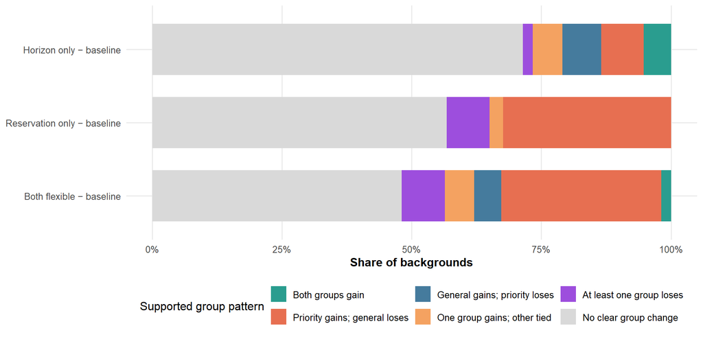

Figure 5: Supported Class 1 and Class 2 served-rate patterns for each policy compared with baseline.

- Horizon changes can help or hurt either group because they change the set of delays offered to everyone.
- Reservations more directly redistribute access toward Class 1.
- “Priority gains; general loses” means the paired confidence intervals support both directions. It is not inferred from point estimates alone.

The main strict-reservation trade-off appears under congested conditions:

- Reservation-only produces a supported priority-gain/general-loss pattern in 32.4% of backgrounds.
- Both-flexible produces the same pattern in 30.8%.
- At demand ratios below 1.2, clear group changes are rare.
- As demand rises, reservations increasingly determine **who** receives limited capacity rather than creating additional capacity.

## Comparison with the twice-weighted Class 1 objective

The secondary objective was:

> **Priority-weighted served rate** = [2 × **Class 1 served rate** + **Class 2 served rate**] ÷ 3

Class 1 therefore receives **twice the policy weight** of Class 2. The code stores this metric as `weighted_utilization`.

### What is similar?

- The baseline is identical because it has no parameters to optimize.
- Demand remains the main condition under which policy changes matter.
- Short horizons remain common under both objectives.
- Horizon-only is more stable across objectives than reservation policies.

### What changes?

| Policy | Same exact policy cell | Median average-utilization change | Median weighted-rate change | Average-utilization loss > 0.5 pp | Weighted-rate gain > 0.5 pp | Priority gains; general loses |
| --- | --- | --- | --- | --- | --- | --- |
| Both flexible | 13.0% | -0.32 pp | 0.49 pp | 44.2% | 49.3% | 38.1% |
| Horizon only | 71.0% | 0.00 pp | 0.00 pp | 3.8% | 13.0% | 8.5% |
| Reservation only | 16.9% | -0.32 pp | 0.41 pp | 43.7% | 47.0% | 37.1% |

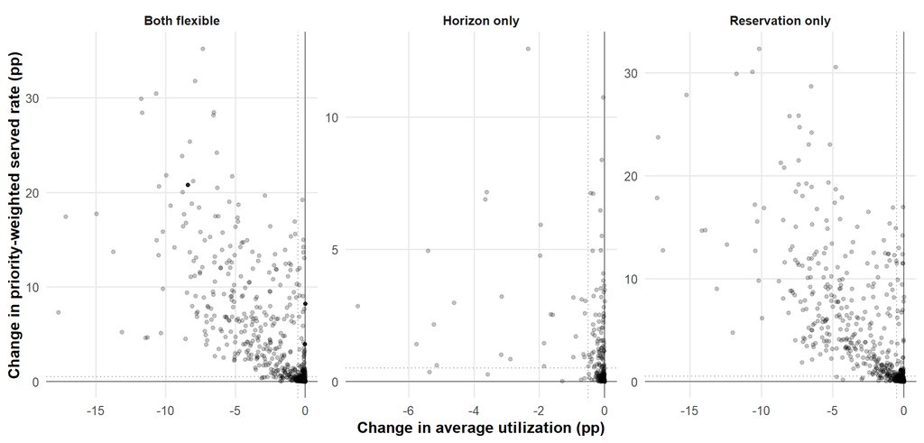

Figure 6: Changing from the average-utilization optimum to the twice-weighted Class 1 optimum. Upper-left observations gain priority-weighted access while losing average utilization.

The weighted objective mainly changes reservation design:

- For reservation-only, switching to the weighted optimum changes average utilization by a median of -0.32 pp and raises the weighted served rate by 0.41 pp.
- For both-flexible, the corresponding medians are -0.32 pp and 0.49 pp.
- The trade-off is strongest when the priority group is small or moderate and demand is high. More capacity can be redirected to Class 1, but strict unused reservations cannot be recovered.
- Horizon-only is much more similar across objectives because it changes access timing for both groups rather than reserving capacity for one group.

## Brief comparison with the companion report

The same-day-release report shows the same broad demand pattern, but release changes reservation behavior:

- Reservation-only has a supported utilization increase in 19.0% of strict backgrounds versus 22.5% under release.
- Release permits much larger nominal reservation quantities because unused slots can return to the general pool.
- The weighted-access objective imposes a smaller average-utilization penalty under release than under strict reservation.

## Conclusions

- **Low and moderate demand:** practical ties dominate; policy flexibility usually adds little average utilization.
- **Heavy demand:** short horizons drive the largest gains. Reservations can add further value when the general group has high no-show risk.
- **Single-policy comparison:** reservation-only and horizon-only each win in some backgrounds; most are tied.
- **Access distribution:** strict reservations frequently raise priority-group access while reducing general-group access.
- **Objective choice matters:** giving Class 1 twice the policy weight often changes `Q` and the reservation window and can reduce total utilization.